# Reproducible Research - Course Project 1

Autor: Lillyan Paes Barreto Date: 10-30-2016

# Loading the Data

This first part reads the data into R. This data regards the number of steps taken by an individual each day from October,2012 to November, 2012.The file “activity.csv” must be in the working directory.

```r
if(!file.exists("getdata-projectfiles-UCI HAR Dataset.zip")) {
        temp <- tempfile()
        download.file("http://d396qusza40orc.cloudfront.net/repdata%2Fdata%2Factivity.zip",temp)
        unzip(temp)
        unlink(temp)

data = read.csv("activity.csv")
}
```

# What is the mean total number of steps taken per day?

In this part, I calculate the total number of steps taken per day. Then, I create the histogram of the total number of steps taken each day. At ;last, I compute the mean and median of the steps taken per day.

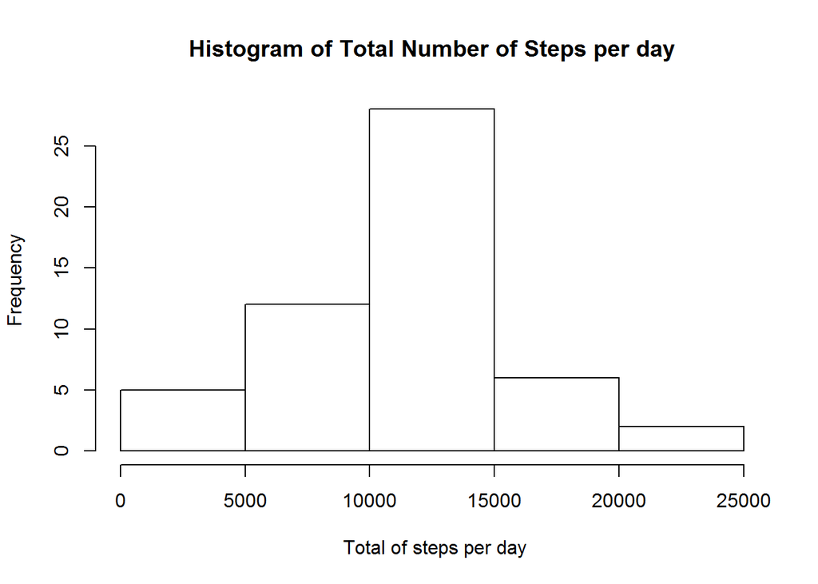

```r
library(plyr)
stepssum = ddply(data,.(date),summarize,sum = sum(steps))
mean.na = mean(stepssum$sum,na.rm = TRUE)
median.na = median(stepssum$sum,na.rm = TRUE)
hist(stepssum$sum,main = "Histogram of Total Number of Steps per day",xlab =" Total of steps per day")
```

# What is the average daily activity pattern?

Here is the time series plot of the average number of steps taken during a given interval of the day.

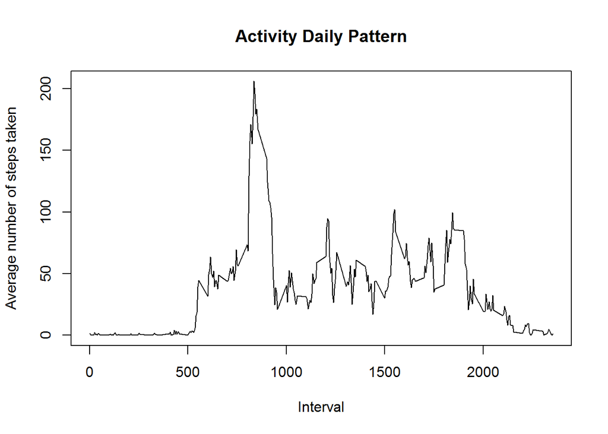

```r
stepsinterval = aggregate(steps ~ interval, data, FUN = mean)
plot(stepsinterval$interval,stepsinterval$steps, type = "l",xlab = "Interval",ylab = "Average number of steps taken",main = "Activity Daily Pattern")
```

Now, I find the interval when we have maximum activity.

```r
maxinterval = subset(stepsinterval,stepsinterval$steps == max(stepsinterval$steps))
maxinterval = maxinterval[,1]
```

In the interval 835, I have the maximum number of steps.

# Imputing missing values

```r
numberofnas = table(is.na(data)["TRUE"])
```

I am going to substitute the missing values with the average number of steps in each interval. Then, I am going to create the histogram of the total of steps taken in a day.

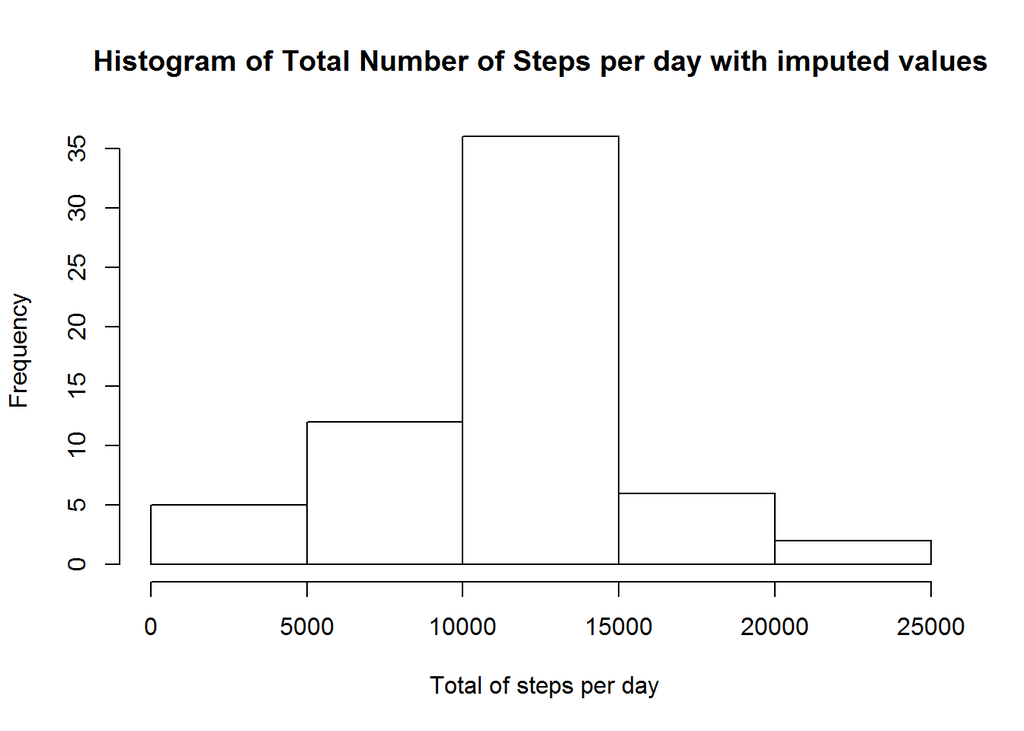

```r
data$steps = ifelse(is.na(data$steps), stepsinterval$steps[match(data$interval, stepsinterval$interval)], data$steps)
stepssumimp = ddply(data,.(date),summarize,sum = sum(steps))
meanimp = mean(stepssumimp$sum,na.rm = TRUE)
medianimp = median(stepssumimp$sum,na.rm = TRUE)
hist(stepssumimp$sum,main = "Histogram of Total Number of Steps per day with imputed values",xlab =" Total of steps per day")
```

# Are there differences in activity patterns between weekdays and weekends?

Here I transform the dates in days of the week and create a new variable that segregates the weekdays and weekends. Then, I create the following panel plot in order to compare the activity daily pattern during weekdays and weekends.

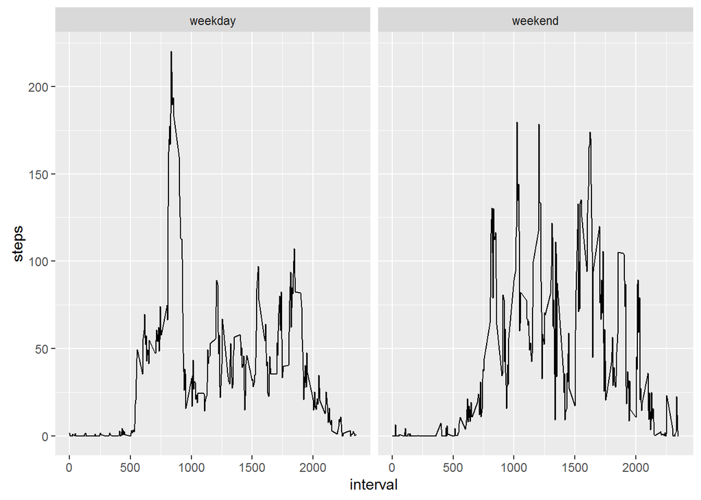

```r
library(ggplot2)
data$date = as.POSIXct(data$date,tz = "GMT", "%Y-%m-%d")
data$date = weekdays(data$date)
data$daytype = ifelse(data$date == "s??bado"|data$date == "domingo","weekend","weekday")
data = aggregate(steps ~ daytype + interval,data,mean)
ggplot(data,aes(interval,steps))+facet_grid(.~daytype)+geom_line(aes(interval,steps))
```